# Auto-approval & Auto-refusal clusters.

### Кредиты наличными. Без предодобренных.

#### **Поиск критериев для для отнесения заявки в группу “автоодобрение” или “автоотказ”.**

##### Критерий качества выдач - was.ovd90.12m.

###### *Галкин Михаил, сен.2017*

*Исходные данные:*  
- 161 490 заявки за период [03.01.2014 - 30.06.2016].  
- 51 770 выданных кредитов наличными.  
- 109 720 отказов.

| Сегмент | Кол-во заявок | в них: Выдач, % | в выданных: was.ovd90.12m, % |
| --- | --- | --- | --- |
| Открытый рынок | 70 165 | 21.28982 | 4.686036 |
| Корп. канал | 44 913 | 37.09616 | 3.481184 |
| Бюджетники | 13 693 | 30.48273 | 4.144705 |
| ЗП клиенты | 32 719 | 48.89208 | 1.600300 |
| ВСЕГО | 161 490 | 32.05771 | 3.301140 |

- 328 различных параметров, разбитых на условные “Группы”:
1. **application** - данные из заявки на кредит.
2. **bki** - данные полученные от различных БКИ.
3. **calculation** - данные расчитываемые в процессе принятия решения о выдаче.
4. **furfsr** - список ФУРов и ФСРов.
5. **info** - дополнительная информация о клиенте.
6. **rbo** - информация о клиенте из РБО.
7. **rbo.behavior** - “поведенческий скоринг” из РБО.

*Техника анализа:*

1. В каждой группе оцениваем важность каждого параметра для целевой переменной **was.ovd90.12m**.
2. После оценки, из каждой группы берём по топ-10 параметров. В результате имеем 65 самых важных параметров (примечание: в *calculation* 5 параметров).
3. По отобранным 65-ти параметрам проводим кластеризацию всех имеющихся заявок. В итоге каждая заявка будет отнесена в один из N узлов (кластеров).
4. Для каждого полученного узла считаем уровень одобрения (**%Approval**) и уровень дефолта (**%was.ovd90.12m**). Нас будут интересовать 2 типа узлов:
   - С высоким уровнем одобрения и высоким уровнем качества. Это потенциальные кандидаты на **автоодобрение**. Обозначим эту группу узлов как **zona HIGH**.
   - С низким уровнем одобрения и низким уровнем качества. Это потенциальные кандидаты на **автоотказ**. Обозначим эту группу узлов как **zona LOW**.
5. Далее определяем каждый узел (кластер) в одну из 3-х зон:
   - **zona HIGH**: Это узлы, которые входят в квантиль [80-100] по %Approval (т.е это 20% узлов от всего их кол-ва, с наибольшим уровнем одобрения) и одновременно входят в квантиль [0-20] по %was.ovd90.12m (т.е в 20% узлов с наименьшим уровнем дефолта).
   - **zona LOW**: Это узлы, которые входят в квантиль [0-20] по %Approval (т.е это 20% узлов с наименьшим уровнем одобрения) и одновременно входят в квантиль [80-100] по %was.ovd90.12m (т.е в 20% узлов с наибольшим уровнем дефолта).
   - **zona ANY**: Это узлы, которые не вошли ни в зону HIGH, ни в зону LOW.

   Таким образом каждая заявка получит признак HIGH, LOW или ANY, в зависимости от того, в какую зону попал узел, к которому она принадлежит.
6. Теперь с помощью теста Краскела-Уоллиса проверяем независимость зон HIGH, LOW или ANY в каждом из 328 параметров заявки и определяем те параметры, которые статистически достоверно имеют различия в трёх зонах. Для надёжности будем использовать критерий значимости p-value = 1%.
7. Среди отобранных на предыдущем шаге параметров, проводим тройной парный тест Вилкоксона (с уровнем p-value = 1%) на независимость и находим те параметры, которые статистически отличаются для всех пар зон: HIGH-LOW, HIGH-ANY и LOW-ANY. В результате получаем список параметров, которые могут использоваться для классификации заявок по зонам. Назовём этот список как **“Влияющие параметры”**.
8. Оценим важность каждого из *влияющих параметров* для классификации заявок по зонам HIGH или LOW или ANY. Параметры, в сумме дающие 95% важности, выделим в группу **“Значимые параметры”**.
9. Рассмотрим зональные распределения данных *значимых параметров* индивидуально и найдем для каждого из них решающую границу между зон HIGH-LOW.
10. На *значимых параметрах* попробуем построить примитивное дерево решений* для зон HIGH-LOW.

###### *Примечание*: * Использовать полученное(-ые) деревья для классификации заявок не есть самый верный подход. Правильнее и надёжнее - на значимых параметрах обучить модель множественной классификации (подозреваю, что лучшая будет на ансабле случайных лесов) и использовать её.

### Результат.

#### Шаги 1-2:

Оценка важности и отбор параметров был проведён ранее в рамках анализа важности параметров по критерию was.ovd90.12m.

#### Шаг 3:

Кластеризацию заявок проводим с помощью самоорганизующихся карт Кохонена. Построим карту размером 40х40 узлов.

###### *Самоорганизующаяся карта Кохонена (SOM) - это нейронная сеть с обучением без учителя, выполняющая задачу кластеризации и визуализации. Кластеризация происходит по принципу максимальной похожести (близости) наблюдений друг с другом по всему вектору параметров. В процессе обучения алгоритм разносит заявки по ячейкам-узлам сети и результатом его работы является карта узлов. Каждая ячейка - это один узел или кластер. Близкие по цвету узлы имеют близкие значения какого-либо параметра(-ов).*

В результате построения и обучения карт имеем сеть такого вида:

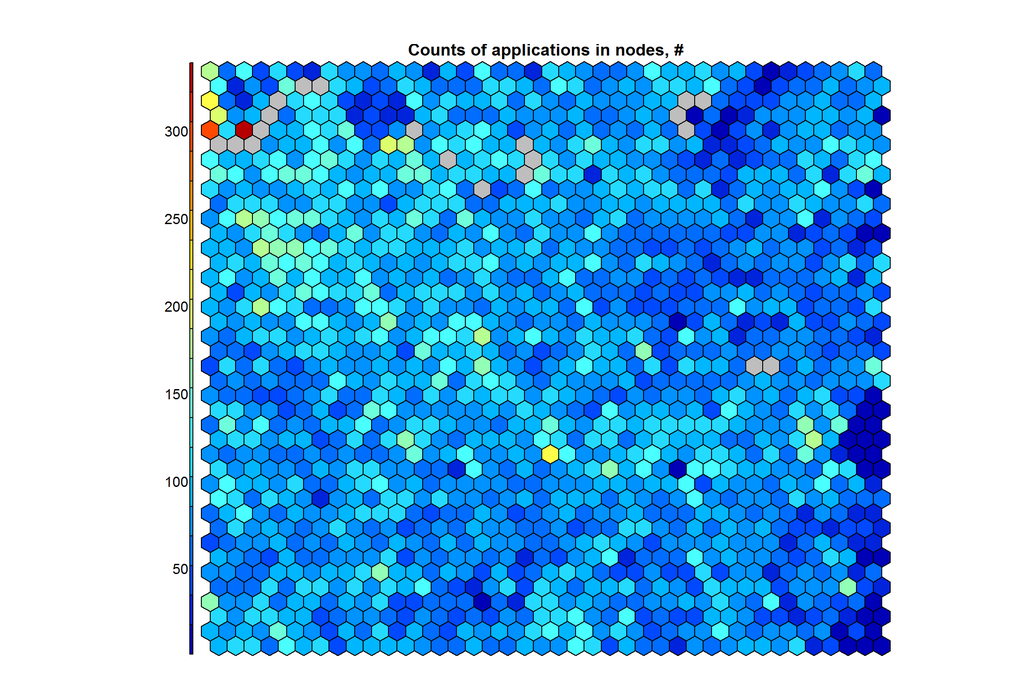

В этой сети карты уровня одобрения (**%Approval**) и уровня дефолта (**%was.ovd90.12m**) представлены так:

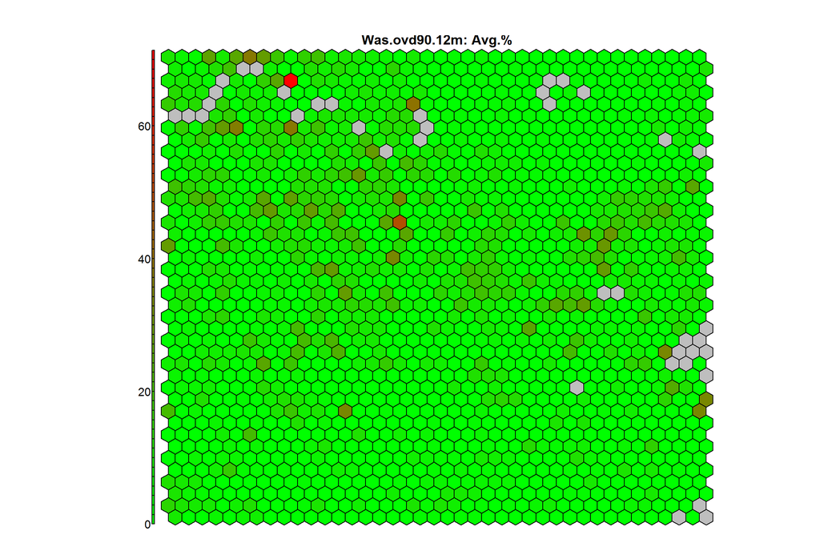

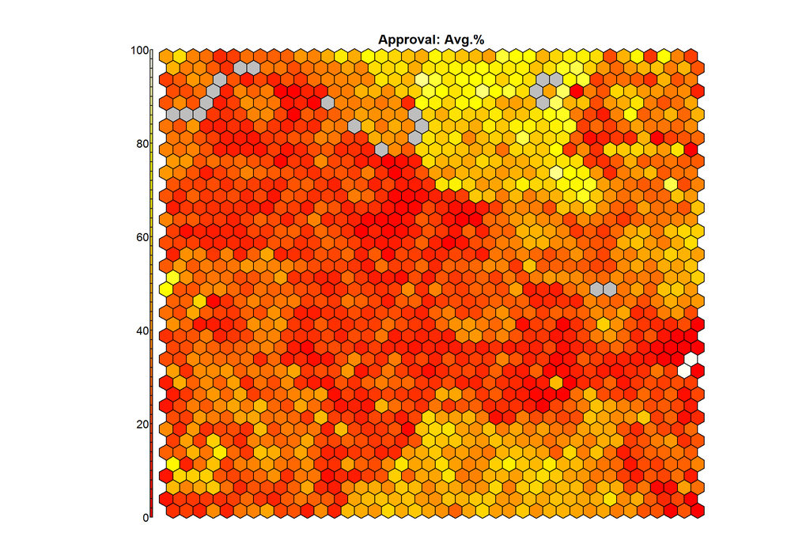

Так выглядит карта выданных кредитов.  
Одна точка = одна заявка. Серые точки - это отказанные заявки. Зелёные точки - это заявки, по которым были выданы кредиты.

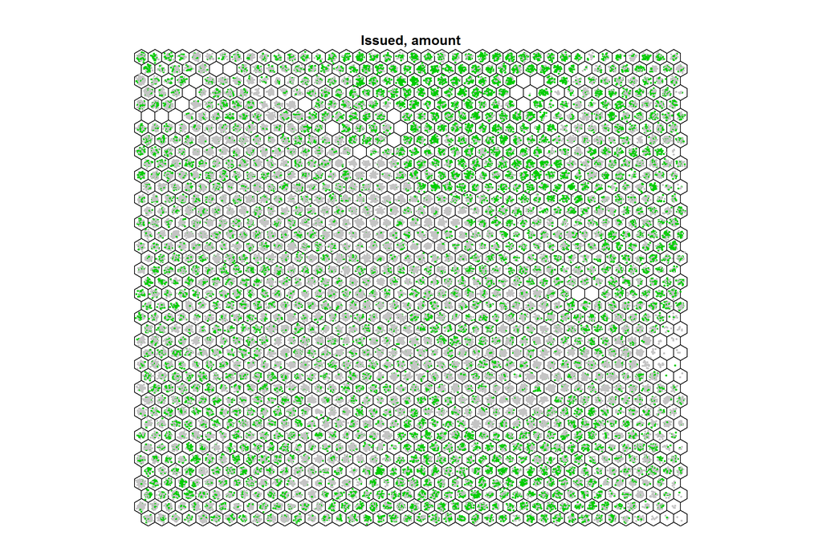

А так, например, выглядит карта возрастов клиентов:

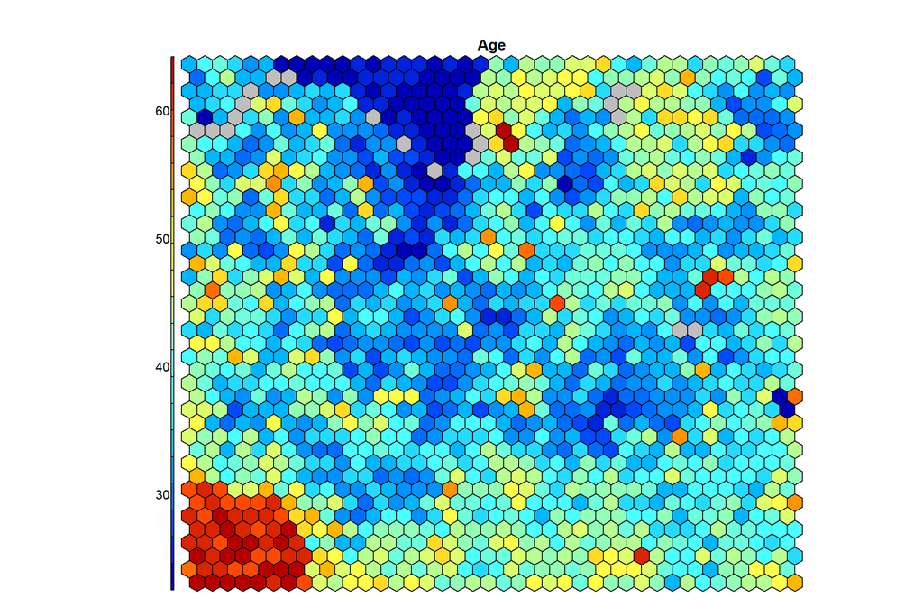

#### Шаги 4-5:

Для каждого узла нашей сети считаем уровень одобрения (**%Approval**) и уровень дефолта (**%was.ovd90.12m**). Далее разбиваем все узлы на квантили и присваиваем каждому из них соответсвующий маркер зоны HIGH, LOW или ANY в зависимости от уровней одобрения и дефолта внутри узла.

На карте найденные узлы выглядят так:  
*- Тёмно-зелёные узлы - это узлы с высоким уровнем одобрения (пропорционален радиусу ярко-зелёного сектора внутри узла) и низким уровнем дефолта (пропорционален радиусу ярко-красного сектора внутри узла), т.е. это зона HIGH.*  
*- Тёмно-красные узлы - это узлы с низким уровнем одобрения и высоким уровнем дефолта, т.е. это зона LOW.*  
*- Чёрные узлы - это узлы в которых был 100% отказ, либо это пустые узлы.*  
*- Все остальные узлы - это зона ANY.*

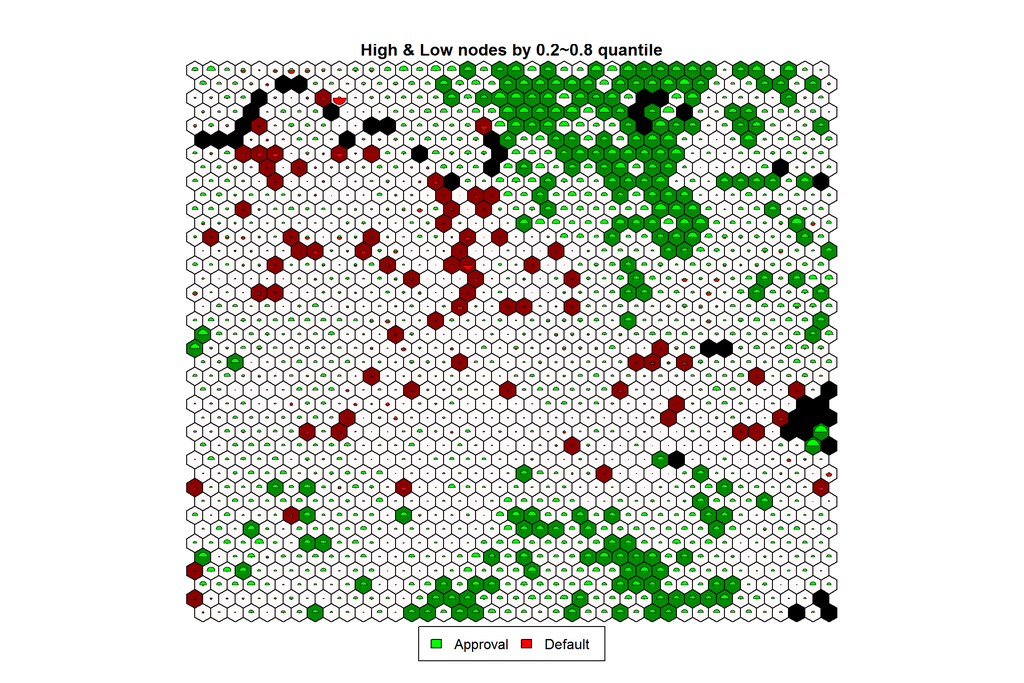

Разброс значений среднего процента одобрения и дефолтности в трёх зонах выглядит так:

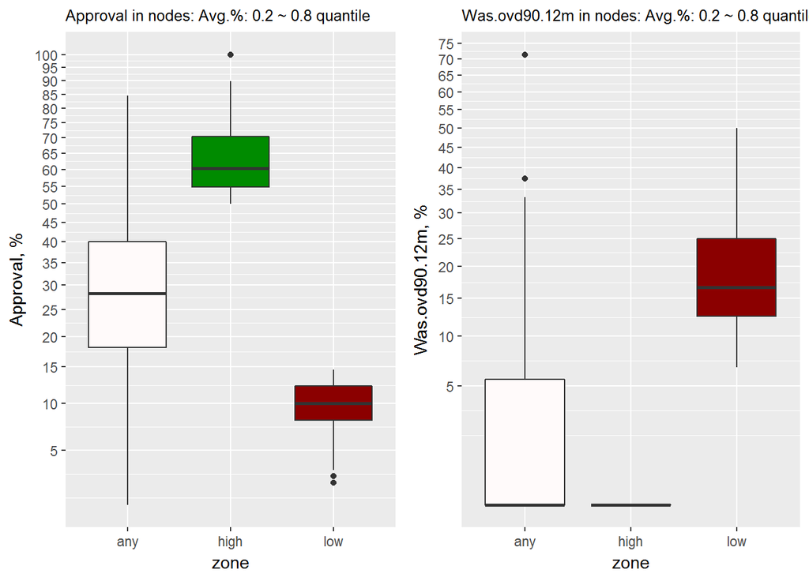

Все узлы сети в системе координат **%Approval** и **%was.ovd90.12m** выглядят следующим образом:  
*- Зелёные пузыри - узлы зоны HIGH.*  
*- Красные пузыри - узлы зоны LOW.*  
*- Серые пузыри - узлы зоны ANY.*  
*- Сплошная зелёная линия - средний уровень одобрения по всем заявкам.*  
*- Красная сплошная линия - средний уровень дефолтности по выданным кредитам.*  
*- Пунктирные линии - соотвествующие границы нижнего (20%) и верхнего (20%) квантилей.*  
*- Размер пузыря пропорционален количеству заявок в узле*  
Нас будут интересовать красные и зелёные узлы:

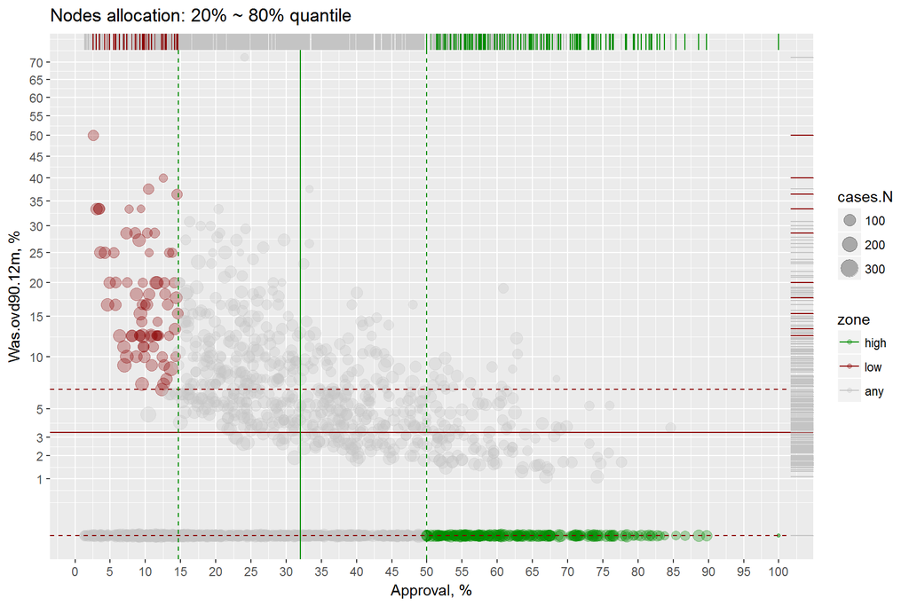

Суммарные значения во трём зонам таковы:

| Зона | Кол-во заявок | % Выдач | % was.ovd90.12m |
| --- | --- | --- | --- |
| any | 107 690 | 29.414987 | 3.952395 |
| high | 14 348 | 62.865905 | 0.000000 |
| low | 6 782 | 9.628428 | 16.232772 |

#### Шаги 6-8:

После последовательного применения статистических тестов на независимость был получен список **“Влияющих параметров”**.  
Влияющий параметр - это параметр у которого, среднее и медианное значения в каждой из трёх зон статистически отличаются между собой с уровнем значимости p-value не больше 1%.

Из списка *влияющих параметров*, после оценки важности каждого из них, получаем группу **значимых** параметров в сумме обеспечивающих 95% важности для трёхзонной (множественной) классификации заявок.

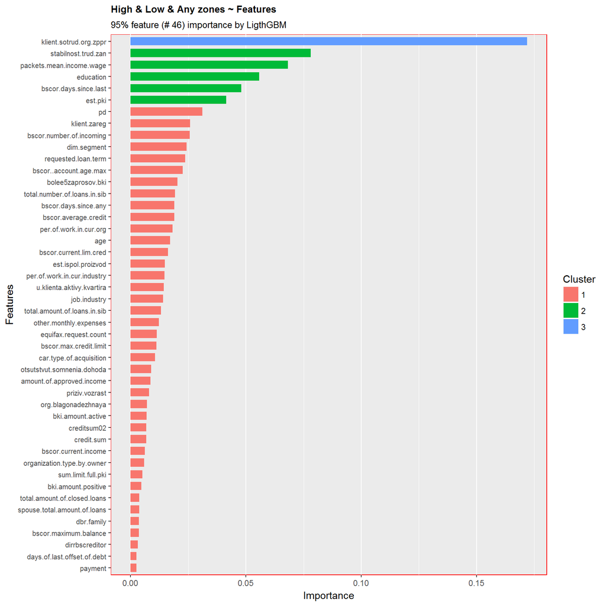

Основные описательные статистики в каждой зоне по каждому **значимому** параметру с верхнего графика приведены в этой таблице:

Среднее, Медиана, Min & Max, Частота появления (для текстовых параметров)

| Feature | Описание | Вес, % | зона HIGH | зона LOW | зона ANY |
| --- | --- | --- | --- | --- | --- |
| klient.sotrud.org.zppr | ФСР: Клиент - сотрудник организации, обслуживающейся в банке на ЗП проекте более 4 мес | 17.1902751 | Avg=0.5109423 Med=1 Min=0 Max=1 %NA=0 | Avg=0.0007372457 Med=0 Min=0 Max=1 %NA=0 | Avg=0.06427709 Med=0 Min=0 Max=1 %NA=0 |
| stabilnost.trud.zan | ФСР: Стабильность трудовой занятости клиента | 7.8038792 | Avg=0.3253415 Med=0 Min=0 Max=1 %NA=0 | Avg=0.002948983 Med=0 Min=0 Max=1 %NA=0 | Avg=0.08440895 Med=0 Min=0 Max=1 %NA=0 |
| packets.mean.income.wage | Пакеты. Средний доход за последние 6 месяцев (только ЗП) | 6.8284831 | Avg=15902.99 Med=6381.83 Min=0 Max=333333.3 %NA=0.1 | Avg=322.6036 Med=0 Min=0 Max=46679.05 %NA=3.3 | Avg=2496.586 Med=0 Min=0 Max=493833.3 %NA=2.4 |
| education | Образование | 5.5802781 | высшее(#7611 - %53.1) All(#14346 - %NA=0) | среднее, в том числе специальное(#3366 - %49.6) All(#6782 - %NA=0) | среднее, в том числе специальное(#46726 - %43.5) All(#107513 - %NA=0.2) |
| bscor.days.since.last | ПОВЕДЕНЧЕСКИЙ СКОРИНГ. Кол-дней прошедших с последней дебитной транзакции_Min | 4.7920923 | Avg=119.7961 Med=8 Min=0 Max=366 %NA=0.1 | Avg=20.04605 Med=0 Min=0 Max=366 %NA=3.3 | Avg=91.34538 Med=0 Min=0 Max=366 %NA=2.4 |
| est.pki | ФСР: У клиента ПКИ в Банке или по данным БКИ | 4.1508260 | Avg=0.3479928 Med=0 Min=0 Max=1 %NA=0 | Avg=0.01179593 Med=0 Min=0 Max=1 %NA=0 | Avg=0.07963599 Med=0 Min=0 Max=1 %NA=0 |
| pd | Probability of Deafault (Вероятность дефолта) | 3.1112166 | Avg=4.908997 Med=3.67 Min=0.28 Max=42.84 %NA=0.1 | Avg=11.33036 Med=8.84 Min=0.67 Max=40.16 %NA=9.5 | Avg=7.976767 Med=5.86 Min=0.28 Max=59.43 %NA=3.9 |
| klient.zareg | ФСР: Клиент зарегистрирован и проживает по одному адресу длительное время (5 лет и более) | 2.5715436 | Avg=0.5280178 Med=1 Min=0 Max=1 %NA=0 | Avg=0.06974344 Med=0 Min=0 Max=1 %NA=0 | Avg=0.2610827 Med=0 Min=0 Max=1 %NA=0 |
| bscor.number.of.incoming | ПОВЕДЕНЧЕСКИЙ СКОРИНГ. Среднее кол-во входящих транзакций за последние 12 мес_Sum | 2.5687783 | Avg=0.06316663 Med=0.05 Min=0 Max=1.97 %NA=0.1 | Avg=0.004121683 Med=0 Min=0 Max=0.13 %NA=3.3 | Avg=0.01760433 Med=0 Min=0 Max=0.8 %NA=2.4 |
| dim.segment | Сегмент | 2.4251652 | зп клиенты(#8925 - %62.2) All(#14348 - %NA=0) | открытый рынок(#4240 - %62.5) All(#6782 - %NA=0) | открытый рынок(#49721 - %46.2) All(#107690 - %NA=0) |
| requested.loan.term | Запрошенный срок кредита | 2.3634387 | Avg=37.38918 Med=36 Min=12 Max=120 %NA=0 | Avg=50.28074 Med=60 Min=12 Max=84 %NA=0 | Avg=45.30738 Med=48 Min=12 Max=360 %NA=0 |
| bscor..account.age.max | ПОВЕДЕНЧЕСКИЙ СКОРИНГ. Возраст текущего счета_Max | 2.2577995 | Avg=43.40014 Med=33.03 Min=0 Max=221.61 %NA=0.1 | Avg=4.131144 Med=0 Min=0 Max=155.06 %NA=3.3 | Avg=18.92262 Med=0 Min=0 Max=215.71 %NA=2.4 |
| bolee5zaprosov.bki | ФУР: Частые запросы в БКИ от сторонних банков за последний месяц | 2.0338990 | Avg=0.02913298 Med=0 Min=0 Max=1 %NA=0 | Avg=0.06163374 Med=0 Min=0 Max=1 %NA=0 | Avg=0.08511468 Med=0 Min=0 Max=1 %NA=0 |
| total.number.of.loans.in.sib | Количество ранее полученных кредитов в САБ клиентом | 1.9280488 | Avg=1.724768 Med=1 Min=0 Max=15 %NA=0.1 | Avg=0.189387 Med=0 Min=0 Max=8 %NA=3.3 | Avg=0.7716455 Med=0 Min=0 Max=25 %NA=2.4 |
| bscor.days.since.any | ПОВЕДЕНЧЕСКИЙ СКОРИНГ. Дней с последней любой транзакции | 1.9012148 | Avg=71.56736 Med=5 Min=-21 Max=366 %NA=7.5 | Avg=76.85185 Med=8 Min=-9 Max=366 %NA=85.7 | Avg=120.6865 Med=16 Min=-25 Max=366 %NA=54.9 |
| bscor.average.credit | ПОВЕДЕНЧЕСКИЙ СКОРИНГ. Средняя сумма кредитной транзакции за последние 12 мес_Aver | 1.8969336 | Avg=8071.772 Med=4644.91 Min=0 Max=262692.3 %NA=0.1 | Avg=1126.538 Med=0 Min=0 Max=106342.5 %NA=3.3 | Avg=5338.249 Med=0 Min=0 Max=4500003 %NA=2.4 |
| per.of.work.in.cur.org | Время работы в данной организации | 1.8185916 | от 1 года до 3 лет(#2382 - %17) All(#14016 - %NA=2.3) | более 3 лет(#2326 - %35.6) All(#6526 - %NA=3.8) | от 1 года до 3 лет(#33207 - %32.3) All(#102873 - %NA=4.5) |
| age | Возраст | 1.7159417 | Avg=41.96938 Med=41 Min=21 Max=73 %NA=0.1 | Avg=35.73425 Med=33 Min=21 Max=72 %NA=3.3 | Avg=37.72496 Med=35 Min=20 Max=75 %NA=2.4 |
| bscor.current.lim.cred | ПОВЕДЕНЧЕСКИЙ СКОРИНГ. Текущий кредитный лимит | 1.6278327 | Avg=165178.4 Med=71283.1 Min=0 Max=2225712 %NA=0.1 | Avg=15927.7 Med=0 Min=0 Max=1168545 %NA=3.3 | Avg=97453.49 Med=0 Min=0 Max=7378753 %NA=2.4 |
| est.ispol.proizvod | ФУР: У клиента есть исполнительные производства | 1.4780553 | Avg=0.7896571 Med=1 Min=0 Max=1 %NA=0 | Avg=0.2431436 Med=0 Min=0 Max=1 %NA=0 | Avg=0.4431702 Med=0 Min=0 Max=1 %NA=0 |
| per.of.work.in.cur.industry | Время работы в этом направлении | 1.4662911 | NA(#NA - %NA) All(#14015 - %NA=2.3) | NA(#NA - %NA) All(#6526 - %NA=3.8) | NA(#NA - %NA) All(#102871 - %NA=4.5) |
| u.klienta.aktivy.kvartira | ФСР: Наличие у Клиента подтвержденных активов - квартира | 1.4396812 | Avg=0.5427237 Med=1 Min=0 Max=1 %NA=0 | Avg=0.4643173 Med=0 Min=0 Max=1 %NA=0 | Avg=0.4177454 Med=0 Min=0 Max=1 %NA=0 |
| job.industry | Отрасль места работы | 1.4024012 | обрабатывающие производства(#1371 - %9.8) All(#14016 - %NA=2.3) | здравоохранение и предоставление социальных услуг(#310 - %4.8) All(#6526 - %NA=3.8) | строительство(#8091 - %7.9) All(#102876 - %NA=4.5) |
| total.amount.of.loans.in.sib | Сумма ранее полученных кредитов в САБ | 1.3096626 | Avg=175732.5 Med=82650 Min=0 Max=3214000 %NA=0.1 | Avg=19604.91 Med=0 Min=0 Max=2534200 %NA=3.3 | Avg=108049.9 Med=0 Min=0 Max=11852285 %NA=2.4 |
| other.monthly.expenses | Прочие расходы (на лечение/сотовую связь и т.д.) | 1.2182121 | Avg=1246.6 Med=650 Min=0 Max=25000 %NA=90.5 | Avg=1257.783 Med=500 Min=0 Max=30000 %NA=86.4 | Avg=1306.23 Med=500 Min=0 Max=100000 %NA=78 |
| equifax.request.count | Количество запросов в Эквифакс за последний месяц | 1.1361102 | Avg=1.102991 Med=1 Min=0 Max=12 %NA=13.3 | Avg=2.052305 Med=1 Min=0 Max=21 %NA=16.8 | Avg=1.76545 Med=1 Min=0 Max=56 %NA=27 |
| bscor.max.credit.limit | ПОВЕДЕНЧЕСКИЙ СКОРИНГ. Максимальное использование кредитного лимита за последние 6 мес_Max | 1.1183894 | Avg=108413.4 Med=52742.62 Min=0 Max=1916570 %NA=0.1 | Avg=10625.33 Med=0 Min=0 Max=736000 %NA=3.3 | Avg=63974.3 Med=0 Min=0 Max=4821304 %NA=2.4 |
| car.type.of.acquisition | Автомобиль - способ приобретения | 1.0641756 | покупка за счет собственных средств(#4520 - %53.9) All(#8382 - %NA=41.6) | покупка за счет собственных средств(#1794 - %42.5) All(#4220 - %NA=37.8) | NA(#NA - %NA) All(#57937 - %NA=46.2) |
| otsutstvut.somnenia.dohoda | ФСР: Отсутствуют сомнения в уровне дохода клиента | 0.8952640 | Avg=0.7336214 Med=1 Min=0 Max=1 %NA=0 | Avg=0.194338 Med=0 Min=0 Max=1 %NA=0 | Avg=0.3508032 Med=0 Min=0 Max=1 %NA=0 |
| amount.of.approved.income | Персональный доход по основному месту работы подтвержден | 0.8596048 | NA(#NA - %NA) All(#14052 - %NA=2.1) | NA(#NA - %NA) All(#6701 - %NA=1.2) | NA(#NA - %NA) All(#104395 - %NA=3.1) |
| priziv.vozrast | ФУР: Призывной возраст клиента | 0.8050877 | Avg=0.02069975 Med=0 Min=0 Max=1 %NA=0 | Avg=0.005897965 Med=0 Min=0 Max=1 %NA=0 | Avg=0.04562169 Med=0 Min=0 Max=1 %NA=0 |
| org.blagonadezhnaya | ФСР: Клиент трудоустроен в организации, относящейся к перечню благонадежных организаций | 0.7047456 | Avg=0.6540981 Med=1 Min=0 Max=1 %NA=0 | Avg=0.1079328 Med=0 Min=0 Max=1 %NA=0 | Avg=0.255019 Med=0 Min=0 Max=1 %NA=0 |
| bki.amount.active | Кредитный портфель по активным кредитам | 0.7002134 | Avg=141534.9 Med=23147.92 Min=0 Max=5465703 %NA=4.3 | Avg=262678.8 Med=42000 Min=0 Max=13459972 %NA=22.2 | Avg=250650.4 Med=58835 Min=0 Max=25250053 %NA=12.3 |
| creditsum02 | Кредит 02: Сумма кредита | 0.6788536 | Avg=119980.2 Med=54970 Min=0 Max=3.8e+07 %NA=46.6 | Avg=101976.2 Med=40443 Min=0 Max=2093000 %NA=93.5 | Avg=122790.7 Med=51005 Min=0 Max=1e+08 %NA=76.5 |
| credit.sum | Сумма кредита | 0.6732800 | Avg=200652.2 Med=158227.9 Min=30000 Max=2650000 %NA=0 | Avg=265595 Med=220000 Min=30000 Max=3e+06 %NA=0 | Avg=258153.4 Med=211864.4 Min=10 Max=8e+06 %NA=0 |
| bscor.current.income | ПОВЕДЕНЧЕСКИЙ СКОРИНГ. Текущий доход клиента_L6M | 0.6218612 | Avg=93852.48 Med=37541.7 Min=0 Max=8466074 %NA=0.1 | Avg=5778.063 Med=0 Min=0 Max=933281 %NA=3.3 | Avg=23515.64 Med=0 Min=0 Max=19199050 %NA=2.4 |
| organization.type.by.owner | Тип организации по отношению к государству | 0.5844467 | NA(#NA - %NA) All(#14016 - %NA=2.3) | NA(#NA - %NA) All(#6526 - %NA=3.8) | NA(#NA - %NA) All(#102868 - %NA=4.5) |
| sum.limit.full.pki | Сумма лимитов погашенных кредитов с ПКИ | 0.5034801 | Avg=212579.6 Med=94857 Min=0 Max=39500000 %NA=17 | Avg=90726.92 Med=0 Min=0 Max=6e+06 %NA=37.5 | Avg=161059.5 Med=23754 Min=0 Max=189115503 %NA=37.1 |
| bki.amount.positive | Сумма кредита по погашенным договорам без просрочек | 0.4618104 | Avg=31386.74 Med=0 Min=0 Max=1.4e+07 %NA=4.3 | Avg=19379.4 Med=0 Min=0 Max=3e+06 %NA=22.2 | Avg=19301.79 Med=0 Min=0 Max=45147000 %NA=12.3 |
| total.amount.of.closed.loans | Совокупная сумма закрытых денежных кредитов | 0.3763571 | Avg=116491.9 Med=30000 Min=0 Max=2727000 %NA=0.1 | Avg=10715.42 Med=0 Min=0 Max=1740000 %NA=3.3 | Avg=68289.15 Med=0 Min=0 Max=11500000 %NA=2.4 |
| spouse.total.amount.of.loans | Сумма ранее полученных кредитов в САБ супругой клиента | 0.3715545 | Avg=13261.69 Med=0 Min=0 Max=1350000 %NA=0.1 | Avg=1872.653 Med=0 Min=0 Max=499371.7 %NA=3.3 | Avg=13804.92 Med=0 Min=0 Max=12175629 %NA=2.4 |
| dbr.family | DBR после выдачи кредита (РАБИС) | 0.3596634 | Avg=0.3659263 Med=0.38 Min=0.003046311 Max=5.927616 %NA=0.1 | Avg=0.4501258 Med=0.41 Min=0 Max=16.97288 %NA=9.5 | Avg=0.7459143 Med=0.41 Min=0 Max=16772.24 %NA=3.9 |
| bscor.maximum.balance | ПОВЕДЕНЧЕСКИЙ СКОРИНГ. Максимальный баланс депозита за последние 6 мес_Max | 0.3581208 | Avg=43148.67 Med=17529.23 Min=0 Max=2028221 %NA=0.1 | Avg=3522.744 Med=0 Min=0 Max=584000 %NA=3.3 | Avg=20073.03 Med=0 Min=0 Max=41256852 %NA=2.4 |
| dirrbscreditor | База наличия кредита в МДМ | 0.3186834 | Avg=2.443069 Med=3 Min=0 Max=3 %NA=25.7 | Avg=1.049051 Med=1 Min=0 Max=3 %NA=17.6 | Avg=1.700736 Med=2 Min=0 Max=3 %NA=27.8 |
| days.of.last.offset.of.debt | Дней с погашения последнего кредита | 0.2598129 | Avg=634.7448 Med=297 Min=-22 Max=3605 %NA=42 | Avg=1280.687 Med=1209 Min=0 Max=3499 %NA=94.4 | Avg=776.6443 Med=429 Min=-26 Max=3660 %NA=73.8 |
| payment | Платеж по выдаваемому кредиту | 0.2576716 | Avg=7605.769 Med=6007.047 Min=827.8927 Max=84982.08 %NA=0.1 | Avg=8639.393 Med=7579.647 Min=0 Max=89700.3 %NA=9.5 | Avg=8703.831 Med=7194.02 Min=0 Max=431895.8 %NA=3.9 |

#### Шаг 10:

Для зон HIGH-LOW на всех *значимых параметрах* построим одно дерево глубиной в 5 уровней:

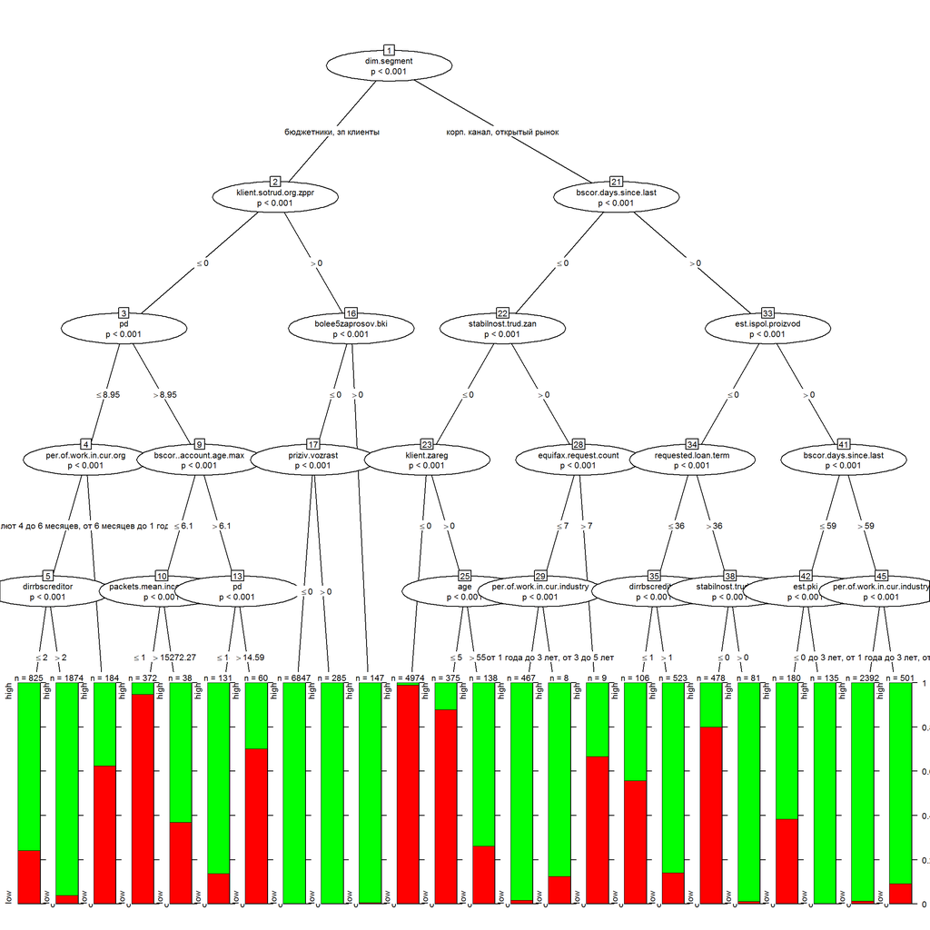

```
##
## Model formula:
## zone ~ klient.sotrud.org.zppr + stabilnost.trud.zan + packets.mean.income.wage +
##     education + bscor.days.since.last + est.pki + pd + klient.zareg +
##     bscor.number.of.incoming + dim.segment + requested.loan.term +
##     bscor..account.age.max + bolee5zaprosov.bki + total.number.of.loans.in.sib +
##     bscor.days.since.any + bscor.average.credit + per.of.work.in.cur.org +
##     age + bscor.current.lim.cred + est.ispol.proizvod + per.of.work.in.cur.industry +
##     u.klienta.aktivy.kvartira + job.industry + total.amount.of.loans.in.sib +
##     other.monthly.expenses + equifax.request.count + bscor.max.credit.limit +
##     car.type.of.acquisition + otsutstvut.somnenia.dohoda + amount.of.approved.income +
##     priziv.vozrast + org.blagonadezhnaya + bki.amount.active +
##     creditsum02 + credit.sum + bscor.current.income + organization.type.by.owner +
##     sum.limit.full.pki + bki.amount.positive + total.amount.of.closed.loans +
##     spouse.total.amount.of.loans + dbr.family + bscor.maximum.balance +
##     dirrbscreditor + days.of.last.offset.of.debt + payment
##
## Fitted party:
## [1] root
## |   [2] dim.segment in бюджетники, зп клиенты
## |   |   [3] klient.sotrud.org.zppr <= 0
## |   |   |   [4] pd <= 8.95
## |   |   |   |   [5] per.of.work.in.cur.org in более 3 лет, от 1 года до 3 лет, от 3 до 4 месяцев
## |   |   |   |   |   [6] dirrbscreditor <= 2: high (n = 825, err = 24.1%)
## |   |   |   |   |   [7] dirrbscreditor > 2: high (n = 1874, err = 3.9%)
## |   |   |   |   [8] per.of.work.in.cur.org in от 4 до 6 месяцев, от 6 месяцев до 1 года: low (n = 184, err = 37.5%)
## |   |   |   [9] pd > 8.95
## |   |   |   |   [10] bscor..account.age.max <= 6.1
## |   |   |   |   |   [11] packets.mean.income.wage <= 15272.27: low (n = 372, err = 5.4%)
## |   |   |   |   |   [12] packets.mean.income.wage > 15272.27: high (n = 38, err = 36.8%)
## |   |   |   |   [13] bscor..account.age.max > 6.1
## |   |   |   |   |   [14] pd <= 14.59: high (n = 131, err = 13.7%)
## |   |   |   |   |   [15] pd > 14.59: low (n = 60, err = 30.0%)
## |   |   [16] klient.sotrud.org.zppr > 0
## |   |   |   [17] bolee5zaprosov.bki <= 0
## |   |   |   |   [18] priziv.vozrast <= 0: high (n = 6847, err = 0.0%)
## |   |   |   |   [19] priziv.vozrast > 0: high (n = 285, err = 0.4%)
## |   |   |   [20] bolee5zaprosov.bki > 0: high (n = 147, err = 0.7%)
## |   [21] dim.segment in корп. канал, открытый рынок
## |   |   [22] bscor.days.since.last <= 0
```

[output cut: 13 more lines]

```
## |   |   |   |   |   [36] dirrbscreditor <= 1: low (n = 106, err = 44.3%)
## |   |   |   |   |   [37] dirrbscreditor > 1: high (n = 523, err = 14.1%)
## |   |   |   |   [38] requested.loan.term > 36
## |   |   |   |   |   [39] stabilnost.trud.zan <= 0: low (n = 478, err = 20.1%)
## |   |   |   |   |   [40] stabilnost.trud.zan > 0: high (n = 81, err = 1.2%)
## |   |   |   [41] est.ispol.proizvod > 0
## |   |   |   |   [42] bscor.days.since.last <= 59
## |   |   |   |   |   [43] est.pki <= 0: high (n = 180, err = 38.3%)
## |   |   |   |   |   [44] est.pki > 0: high (n = 135, err = 0.0%)
## |   |   |   |   [45] bscor.days.since.last > 59
## |   |   |   |   |   [46] per.of.work.in.cur.industry in более 5 лет, менее 1 года: high (n = 2392, err = 1.4%)
## |   |   |   |   |   [47] per.of.work.in.cur.industry in до 3 лет, от 1 года до 3 лет, от 3 до 5 лет: high (n = 501, err = 9.2%)
##
## Number of inner nodes:    23
## Number of terminal nodes: 24
```